# 431 Class 23

Thomas E. Love, Ph.D.

2023-11-28

## Today’s Agenda

- Selecting a multiple linear regression model for prediction of a quantitative outcome
- Incorporating both single and multiple imputation to handle missing data
- Our example: the `msleep` data from the `ggplot2` package in the `tidyverse`

## Today’s Packages

```r
library(janitor)
library(broom)
library(mosaic)
library(gt)
library(car)
library(GGally)
library(naniar); library(simputation)
library(mice); library(mitml)
library(xfun)
library(tidyverse)

theme_set(theme_bw())
```

## The mammals sleep data set (`msleep`)

```r
msleep
```

```
# A tibble: 83 × 11
   name   genus vore  order conservation sleep_total sleep_rem sleep_cycle awake
   <chr>  <chr> <chr> <chr> <chr>              <dbl>     <dbl>       <dbl> <dbl>
 1 Cheet… Acin… carni Carn… lc                  12.1      NA        NA      11.9
 2 Owl m… Aotus omni  Prim… <NA>                17         1.8      NA       7
 3 Mount… Aplo… herbi Rode… nt                  14.4       2.4      NA       9.6
 4 Great… Blar… omni  Sori… lc                  14.9       2.3       0.133   9.1
 5 Cow    Bos   herbi Arti… domesticated         4         0.7       0.667  20
 6 Three… Brad… herbi Pilo… <NA>                14.4       2.2       0.767   9.6
 7 North… Call… carni Carn… vu                   8.7       1.4       0.383  15.3
 8 Vespe… Calo… <NA>  Rode… <NA>                 7        NA        NA      17
 9 Dog    Canis carni Carn… domesticated        10.1       2.9       0.333  13.9
10 Roe d… Capr… herbi Arti… lc                   3        NA        NA      21
# ℹ 73 more rows
# ℹ 2 more variables: brainwt <dbl>, bodywt <dbl>
```

- https://ggplot2.tidyverse.org/reference/msleep.html has details.

## Today’s Variables of Interest

| Variable | Description |
| --- | --- |
| `name` | Common name of mammal |
| `vore` | Carni-, insecti-, herbi- or omnivore |
| `brainwt` | brain weight in kilograms |
| `bodywt` | body weight in kilograms |
| `sleep_rem` | REM sleep, in hours |
| `sleep_total` | total amount of sleep, in hours |
| `awake` | (**outcome**) time spent awake, in hours |

## Modeling Plan

**Note**

Note that `awake` = 24 - `sleep_total`.

We want to predict `awake` using four potential predictors:

- the type of food the mammal consumes (`vore`)
- the weight of the mammal’s brain (`brainwt`)
- the weight of the mammal’s body, (`bodywt`), and
- the proportion of total time asleep spent in REM sleep.

## Creating the `ms431` data

```r
ms431 <- msleep |>
  mutate(rem_prop = sleep_rem / sleep_total) |>
  mutate(vore = factor(vore)) |>
  select(name, vore, brainwt, bodywt, rem_prop, awake)

glimpse(ms431)
```

```
Rows: 83
Columns: 6
$ name     <chr> "Cheetah", "Owl monkey", "Mountain beaver", "Greater short-ta…
$ vore     <fct> carni, omni, herbi, omni, herbi, herbi, carni, NA, carni, her…
$ brainwt  <dbl> NA, 0.01550, NA, 0.00029, 0.42300, NA, NA, NA, 0.07000, 0.098…
$ bodywt   <dbl> 50.000, 0.480, 1.350, 0.019, 600.000, 3.850, 20.490, 0.045, 1…
$ rem_prop <dbl> NA, 0.10588235, 0.16666667, 0.15436242, 0.17500000, 0.1527777…
$ awake    <dbl> 11.9, 7.0, 9.6, 9.1, 20.0, 9.6, 15.3, 17.0, 13.9, 21.0, 18.7,…
```

## Exploring our factor variable

```r
ms431 |> tabyl(vore) |> adorn_pct_formatting() |> gt()
```

| vore | n | percent | valid_percent |
| --- | --- | --- | --- |
| carni | 19 | 22.9% | 25.0% |
| herbi | 32 | 38.6% | 42.1% |
| insecti | 5 | 6.0% | 6.6% |
| omni | 20 | 24.1% | 26.3% |
| NA | 7 | 8.4% | - |

Any concerns here?

## Collapse to three `vore` groups?

```r
favstats(awake ~ vore, data = ms431) |>
  gt() |> fmt_number(columns = min:sd, decimals = 3)
```

| vore | min | Q1 | median | Q3 | max | mean | sd | n | missing |
| --- | --- | --- | --- | --- | --- | --- | --- | --- | --- |
| carni | 4.600 | 11.000 | 13.600 | 17.750 | 21.350 | 13.626 | 4.677 | 19 | 0 |
| herbi | 7.400 | 9.775 | 13.700 | 19.700 | 22.100 | 14.491 | 4.879 | 32 | 0 |
| insecti | 4.100 | 4.300 | 5.900 | 15.400 | 15.600 | 9.060 | 5.921 | 5 | 0 |
| omni | 6.000 | 13.075 | 14.100 | 14.900 | 16.000 | 13.075 | 2.949 | 20 | 0 |

```r
ggplot(ms431, aes(x = awake, y = vore)) + geom_boxplot()
```

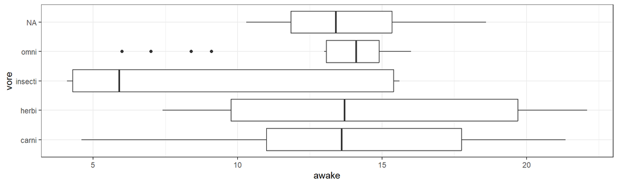

## Exploring our quantities

```r
df_stats(~ brainwt + bodywt + rem_prop + awake, data = ms431) |>
  gt() |> fmt_number(columns = min:sd, decimals = 3)
```

| response | min | Q1 | median | Q3 | max | mean | sd | n | missing |
| --- | --- | --- | --- | --- | --- | --- | --- | --- | --- |
| brainwt | 0.000 | 0.003 | 0.012 | 0.126 | 5.712 | 0.282 | 0.976 | 56 | 27 |
| bodywt | 0.005 | 0.174 | 1.670 | 41.750 | 6,654.000 | 166.136 | 786.840 | 83 | 0 |
| rem_prop | 0.037 | 0.113 | 0.156 | 0.227 | 0.347 | 0.174 | 0.072 | 61 | 22 |
| awake | 4.100 | 10.250 | 13.900 | 16.150 | 22.100 | 13.567 | 4.452 | 83 | 0 |

Any concerns here?

## A `brainwt` of 0?

```r
which.min(ms431$brainwt)
```

```
[1] 17
```

```r
slice(ms431, 17)
```

```
# A tibble: 1 × 6
  name                      vore  brainwt bodywt rem_prop awake
  <chr>                     <fct>   <dbl>  <dbl>    <dbl> <dbl>
1 Lesser short-tailed shrew omni  0.00014  0.005    0.154  14.9
```

- How many of these mammals have a brainwt below 0.01 kg?

```r
ms431 |> filter(brainwt < 0.01) |> nrow()
```

```
[1] 23
```

## Collinearity Check

```r
vif(lm(awake ~ vore + bodywt + brainwt + rem_prop, data = ms431))
```

```
             GVIF Df GVIF^(1/(2*Df))
vore     1.571683  3        1.078270
bodywt   1.658313  1        1.287755
brainwt  1.459939  1        1.208280
rem_prop 1.310584  1        1.144807
```

```r
cor(ms431$bodywt, ms431$brainwt, use = "complete.obs")
```

```
[1] 0.9337822
```

## Change our set of variables?

What if we included

- `brain_prop`: brain weight as a proportion of body weight

along with `bodywt` in our model?

```r
ms431 <- ms431 |>
  mutate(brain_prop = brainwt / bodywt) |>
  select(name, vore, bodywt, brain_prop, rem_prop, awake)

vif(lm(awake ~ vore + bodywt + brain_prop + rem_prop, data = ms431))
```

```
               GVIF Df GVIF^(1/(2*Df))
vore       1.685346  3        1.090891
bodywt     1.277174  1        1.130121
brain_prop 1.330301  1        1.153387
rem_prop   1.346185  1        1.160252
```

OK. Let’s move on to think about missingness.

## How much missingness do we have?

```r
miss_var_summary(ms431)
```

```
# A tibble: 6 × 3
  variable   n_miss pct_miss
  <chr>       <int>    <dbl>
1 brain_prop     27    32.5
2 rem_prop       22    26.5
3 vore            7     8.43
4 name            0     0
5 bodywt          0     0
6 awake           0     0
```

```r
miss_case_table(ms431)
```

```
# A tibble: 4 × 3
  n_miss_in_case n_cases pct_cases
           <int>   <int>     <dbl>
1              0      43     51.8
2              1      26     31.3
3              2      12     14.5
4              3       2      2.41
```

## Missing Data Mechanisms

- **Missing completely at random** There are no systematic differences between the missing values and the observed values.
  - For example, blood pressure measurements may be missing because of breakdown of an automatic sphygmomanometer.
- **Missing at random** Any systematic difference between the missing and observed values can be explained by other observed data.
  - For example, missing BP measurements may be lower than measured BPs but only because younger people more often have a missing BP.
- **Missing not at random** Even after the observed data are taken into account, systematic differences remain between the missing values and the observed values.
  - For example, people with high BP may be more likely to have headaches that cause them to miss clinic appointments.

“Missing at random” is an **assumption** that justifies the analysis, rather than a property of the data.

## What assumption should we use?

Can we assume the data are MCAR, per Little’s test?

```r
mcar_test(ms431)
```

```
# A tibble: 1 × 4
  statistic    df p.value missing.patterns
      <dbl> <dbl>   <dbl>            <int>
1      33.5    22  0.0549                6
```

**Reference**

Little, Roderick J. A. 1988. “A Test of Missing Completely at Random for Multivariate Data with Missing Values.” *Journal of the American Statistical Association* 83 (404): 1198–1202. [doi:10.1080/01621459.1988.10478722](https://www.tandfonline.com/doi/abs/10.1080/01621459.1988.10478722).

## If not MCAR, then what?

Suppose we assume that the data are MAR. This suggests the need for imputation of missing values.

**Note**

If we were willing to assume MCAR, we could simply do a complete case analysis.

Here, we have complete data on our outcome (`awake`) and `bodywt` so we won’t need to impute them.

- We will need to impute `vore` (7), `brain_prop` (27) and `rem_prop` (22) from our sample of 83 mammals.
- `vore` is a factor, the others are quantities.

## Single Imputation

We’ll create a singly imputed data set first, to select our predictors.

```r
ms431_imp <- ms431 |>
  impute_cart(vore ~ awake + bodywt) |>
  impute_pmm(brain_prop ~ vore + awake + bodywt) |>
  impute_pmm(rem_prop ~ brain_prop + vore + awake + bodywt)

prop_complete(ms431); prop_complete(ms431_imp)
```

```
[1] 0.8875502
```

```
[1] 1
```

**Note**

After we’ve settled on a final prediction model using `ms431_imp`, we’ll implement multiple imputation.

## Range Check for impossible values?

```r
ms431_imp |> tabyl(vore) |> adorn_pct_formatting() |> gt()
```

| vore | n | percent |
| --- | --- | --- |
| carni | 19 | 22.9% |
| herbi | 37 | 44.6% |
| insecti | 5 | 6.0% |
| omni | 22 | 26.5% |

```r
df_stats(~ brain_prop + bodywt + rem_prop + awake, data = ms431_imp) |>
  gt() |> fmt_number(columns = min:sd, decimals = 3)
```

| response | min | Q1 | median | Q3 | max | mean | sd | n | missing |
| --- | --- | --- | --- | --- | --- | --- | --- | --- | --- |
| brain_prop | 0.001 | 0.004 | 0.008 | 0.012 | 0.040 | 0.010 | 0.008 | 83 | 0 |
| bodywt | 0.005 | 0.174 | 1.670 | 41.750 | 6,654.000 | 166.136 | 786.840 | 83 | 0 |
| rem_prop | 0.037 | 0.129 | 0.175 | 0.217 | 0.347 | 0.178 | 0.064 | 83 | 0 |
| awake | 4.100 | 10.250 | 13.900 | 16.150 | 22.100 | 13.567 | 4.452 | 83 | 0 |

## Partitioning the `ms431_imp` data

- Do we have a unique name to identify each mammal?

```r
n_distinct(ms431_imp$name) == nrow(ms431_imp) # compare numbers
```

```
[1] TRUE
```

```r
near(n_distinct(ms431_imp$name), nrow(ms431_imp)) # tidyverse approach
```

```
[1] TRUE
```

- Partition 70% into training sample, remaining 30% to test, while maintaining a similar percentage by `vore` groups.

```r
set.seed(20231128)
ms431_train <- slice_sample(ms431_imp, prop = 0.7, by = "vore")
ms431_test <- anti_join(ms431_imp, ms431_train, by = "name")

dim(ms431_train); dim(ms431_test)
```

```
[1] 56  6
```

```
[1] 27  6
```

## Outcome transformation?

```r
boxCox(lm(awake ~ vore + bodywt + brain_prop + rem_prop, data = ms431_train))
```

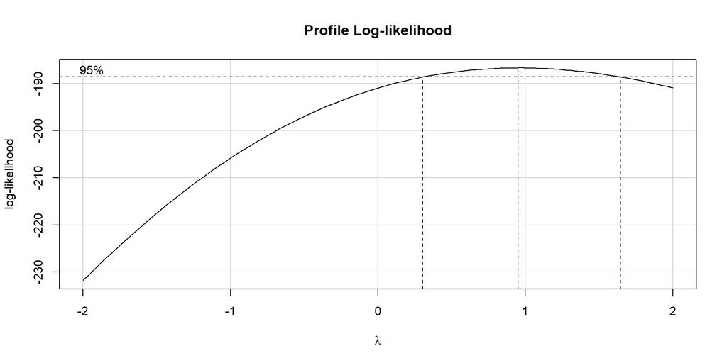

## Scatterplot Matrix

```r
ggpairs(ms431_train |> select(vore, bodywt, brain_prop, rem_prop, awake))
```

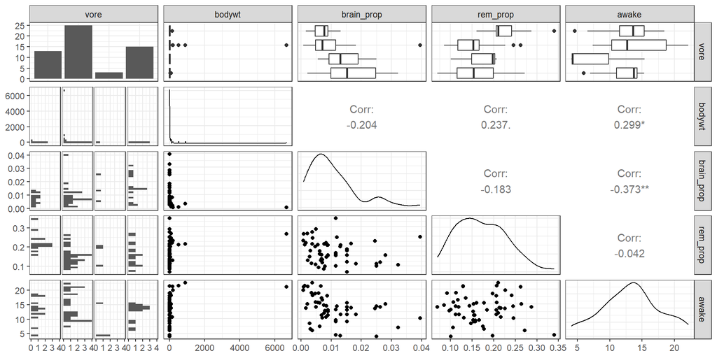

## Collinearity Check in Training Sample

```r
vif(lm(awake ~ vore + bodywt + brain_prop + rem_prop, data = ms431_train))
```

```
               GVIF Df GVIF^(1/(2*Df))
vore       1.801339  3        1.103060
bodywt     1.195728  1        1.093494
brain_prop 1.296357  1        1.138577
rem_prop   1.527369  1        1.235868
```

## Which Potential Models Will We Fit?

- Model 1: A simple regression on `bodywt`
- Model 2: A simple regression on `brain_prop`
- Model 3: A model with the two size variables (`brain_prop` and `bodywt`)
- Model 4: Model 3 + `vore`
- Model 5: Model 3 + `rem_prop`
- Model 6: All four predictors

## Model 6

```r
m6 <- lm(awake ~ bodywt + brain_prop + vore + rem_prop, data = ms431_train)
tidy(m6, conf.int = T, conf.level = 0.90) |> gt()
```

| term | estimate | std.error | statistic | p.value | conf.low | conf.high |
| --- | --- | --- | --- | --- | --- | --- |
| (Intercept) | 1.660338e+01 | 2.897601590 | 5.7300411 | 6.081646e-07 | 1.174540e+01 | 21.461352695 |
| bodywt | 1.232369e-03 | 0.000660803 | 1.8649565 | 6.818189e-02 | 1.244990e-04 | 0.002340239 |
| brain_prop | -1.703350e+02 | 73.982752088 | -2.3023610 | 2.560320e-02 | -2.943709e+02 | -46.299156960 |
| voreherbi | 5.741100e-01 | 1.650939028 | 0.3477476 | 7.295192e-01 | -2.193773e+00 | 3.341993347 |
| voreinsecti | -4.388471e+00 | 2.687230803 | -1.6330830 | 1.088618e-01 | -8.893750e+00 | 0.116808282 |
| voreomni | 2.338684e-01 | 1.774288371 | 0.1318097 | 8.956745e-01 | -2.740816e+00 | 3.208553202 |
| rem_prop | -1.073248e+01 | 11.531936386 | -0.9306749 | 3.565845e-01 | -3.006636e+01 | 8.601394486 |

```r
glance(m6) |> select(r.squared, adj.r.squared, sigma, AIC, BIC, nobs,
                     df, df.residual, everything()) |> gt()
```

| r.squared | adj.r.squared | sigma | AIC | BIC | nobs | df | df.residual | statistic | p.value | logLik | deviance |
| --- | --- | --- | --- | --- | --- | --- | --- | --- | --- | --- | --- |
| 0.2767224 | 0.1881578 | 4.007779 | 322.9259 | 339.1287 | 56 | 6 | 49 | 3.124527 | 0.0113248 | -153.463 | 787.0523 |

## Model 5

```r
m5 <- lm(awake ~ bodywt + brain_prop + rem_prop, data = ms431_train)
tidy(m5, conf.int = T, conf.level = 0.90) |> gt()
```

| term | estimate | std.error | statistic | p.value | conf.low | conf.high |
| --- | --- | --- | --- | --- | --- | --- |
| (Intercept) | 1.724565e+01 | 1.994796e+00 | 8.645323 | 1.233912e-11 | 1.390499e+01 | 20.586315601 |
| bodywt | 1.330198e-03 | 6.371816e-04 | 2.087627 | 4.174828e-02 | 2.631164e-04 | 0.002397279 |
| brain_prop | -1.870432e+02 | 6.770321e+01 | -2.762693 | 7.907186e-03 | -3.004250e+02 | -73.661346290 |
| rem_prop | -1.303002e+01 | 9.797078e+00 | -1.329991 | 1.893257e-01 | -2.943708e+01 | 3.377038136 |

```r
glance(m5) |> select(r.squared, adj.r.squared, sigma, AIC, BIC, nobs,
                     df, df.residual, everything()) |> gt()
```

| r.squared | adj.r.squared | sigma | AIC | BIC | nobs | df | df.residual | statistic | p.value | logLik | deviance |
| --- | --- | --- | --- | --- | --- | --- | --- | --- | --- | --- | --- |
| 0.2175504 | 0.1724091 | 4.046465 | 321.3296 | 331.4563 | 56 | 3 | 52 | 4.819319 | 0.004912293 | -155.6648 | 851.4417 |

## Model 4

```r
m4 <- lm(awake ~ bodywt + brain_prop + vore, data = ms431_train)
tidy(m4, conf.int = T, conf.level = 0.90) |> gt()
```

| term | estimate | std.error | statistic | p.value | conf.low | conf.high |
| --- | --- | --- | --- | --- | --- | --- |
| (Intercept) | 1.416460e+01 | 1.235027e+00 | 11.4690616 | 1.309482e-15 | 1.209481e+01 | 16.234385199 |
| bodywt | 1.032018e-03 | 6.239171e-04 | 1.6540949 | 1.043736e-01 | -1.360770e-05 | 0.002077644 |
| brain_prop | -1.647827e+02 | 7.364305e+01 | -2.2375867 | 2.973430e-02 | -2.882015e+02 | -41.363953320 |
| voreherbi | 1.403785e+00 | 1.387696e+00 | 1.0115937 | 3.166028e-01 | -9.218624e-01 | 3.729431824 |
| voreinsecti | -3.838035e+00 | 2.617827e+00 | -1.4661148 | 1.488783e-01 | -8.225264e+00 | 0.549194338 |
| voreomni | 8.345689e-01 | 1.650511e+00 | 0.5056427 | 6.153294e-01 | -1.931531e+00 | 3.600668649 |

```r
glance(m4) |> select(r.squared, adj.r.squared, sigma, AIC, BIC, nobs,
                     df, df.residual, everything()) |> gt()
```

| r.squared | adj.r.squared | sigma | AIC | BIC | nobs | df | df.residual | statistic | p.value | logLik | deviance |
| --- | --- | --- | --- | --- | --- | --- | --- | --- | --- | --- | --- |
| 0.2639373 | 0.190331 | 4.002411 | 321.9072 | 336.0846 | 56 | 5 | 50 | 3.585799 | 0.00754889 | -153.9536 | 800.9647 |

## Model 3

```r
m3 <- lm(awake ~ bodywt + brain_prop, data = ms431_train)
tidy(m3, conf.int = T, conf.level = 0.90) |> gt()
```

| term | estimate | std.error | statistic | p.value | conf.low | conf.high |
| --- | --- | --- | --- | --- | --- | --- |
| (Intercept) | 1.489038e+01 | 9.248588e-01 | 16.100162 | 4.643318e-22 | 1.334205e+01 | 16.438697093 |
| bodywt | 1.154197e-03 | 6.277933e-04 | 1.838499 | 7.159523e-02 | 1.031981e-04 | 0.002205196 |
| brain_prop | -1.742794e+02 | 6.750396e+01 | -2.581766 | 1.263053e-02 | -2.872889e+02 | -61.269938768 |

```r
glance(m3) |> select(r.squared, adj.r.squared, sigma, AIC, BIC, nobs,
                     df, df.residual, everything()) |> gt()
```

| r.squared | adj.r.squared | sigma | AIC | BIC | nobs | df | df.residual | statistic | p.value | logLik | deviance |
| --- | --- | --- | --- | --- | --- | --- | --- | --- | --- | --- | --- |
| 0.190934 | 0.1604032 | 4.075711 | 321.2028 | 329.3042 | 56 | 2 | 53 | 6.253817 | 0.003643971 | -156.6014 | 880.4051 |

## Model 2

```r
m2 <- lm(awake ~ brain_prop, data = ms431_train)
tidy(m2, conf.int = T, conf.level = 0.90) |> gt()
```

| term | estimate | std.error | statistic | p.value | conf.low | conf.high |
| --- | --- | --- | --- | --- | --- | --- |
| (Intercept) | 15.35035 | 0.9097858 | 16.872490 | 3.469538e-23 | 13.82777 | 16.87294 |
| brain_prop | -199.63886 | 67.5202075 | -2.956728 | 4.603406e-03 | -312.63831 | -86.63941 |

```r
glance(m2) |> select(r.squared, adj.r.squared, sigma, AIC, BIC, nobs,
                     df, df.residual, everything()) |> gt()
```

| r.squared | adj.r.squared | sigma | AIC | BIC | nobs | df | df.residual | statistic | p.value | logLik | deviance |
| --- | --- | --- | --- | --- | --- | --- | --- | --- | --- | --- | --- |
| 0.1393358 | 0.1233975 | 4.164562 | 322.665 | 328.741 | 56 | 1 | 54 | 8.742238 | 0.004603406 | -158.3325 | 936.553 |

## Model 1

```r
m1 <- lm(awake ~ bodywt, data = ms431_train)
tidy(m1, conf.int = T, conf.level = 0.90) |> gt()
```

| term | estimate | std.error | statistic | p.value | conf.low | conf.high |
| --- | --- | --- | --- | --- | --- | --- |
| (Intercept) | 12.97824101 | 0.5822556541 | 22.289592 | 6.645725e-29 | 1.200380e+01 | 13.952683642 |
| bodywt | 0.00148539 | 0.0006459815 | 2.299431 | 2.537445e-02 | 4.042979e-04 | 0.002566482 |

```r
glance(m1) |> select(r.squared, adj.r.squared, sigma, AIC, BIC, nobs,
                     df, df.residual, everything()) |> gt()
```

| r.squared | adj.r.squared | sigma | AIC | BIC | nobs | df | df.residual | statistic | p.value | logLik | deviance |
| --- | --- | --- | --- | --- | --- | --- | --- | --- | --- | --- | --- |
| 0.08918226 | 0.07231526 | 4.284184 | 325.8367 | 331.9128 | 56 | 1 | 54 | 5.287383 | 0.02537445 | -159.9184 | 991.1287 |

## Combining `glance()` results

```r
bind_rows(glance(m1) |> mutate(name = "m1"),
          glance(m2) |> mutate(name = "m2"),
          glance(m3) |> mutate(name = "m3"),
          glance(m4) |> mutate(name = "m4"),
          glance(m5) |> mutate(name = "m5"),
          glance(m6) |> mutate(name = "m6")) |>
  select(name, r.squared, adj.r.squared, sigma, AIC, BIC, nobs, df) |>
  gt() |> fmt_number(decimals = 5, columns = 2) |>
    fmt_number(decimals = 4, columns = c(3:4)) |>
    fmt_number(decimals = 0, columns = c(5:6))
```

| name | r.squared | adj.r.squared | sigma | AIC | BIC | nobs | df |
| --- | --- | --- | --- | --- | --- | --- | --- |
| m1 | 0.08918 | 0.0723 | 4.2842 | 326 | 332 | 56 | 1 |
| m2 | 0.13934 | 0.1234 | 4.1646 | 323 | 329 | 56 | 1 |
| m3 | 0.19093 | 0.1604 | 4.0757 | 321 | 329 | 56 | 2 |
| m4 | 0.26394 | 0.1903 | 4.0024 | 322 | 336 | 56 | 5 |
| m5 | 0.21755 | 0.1724 | 4.0465 | 321 | 331 | 56 | 3 |
| m6 | 0.27672 | 0.1882 | 4.0078 | 323 | 339 | 56 | 6 |

## Move forward with `m3`, `m4` and `m5`

```r
test_m3 <- augment(m3, newdata = ms431_test) |> mutate(mod = "m3")
test_m4 <- augment(m4, newdata = ms431_test) |> mutate(mod = "m4")
test_m5 <- augment(m5, newdata = ms431_test) |> mutate(mod = "m5")

test_comp <- bind_rows(test_m3, test_m4, test_m5) |>
  arrange(name, mod)
```

## Comparing Models: Test Sample

```r
test_comp |>
  group_by(mod) |>
  summarize(n = n(),
            MAPE = mean(abs(.resid)),
            RMSPE = sqrt(mean(.resid^2)),
            max_error = max(abs(.resid)),
            median_APE = median(abs(.resid)),
            valid_R2 = cor(awake, .fitted)^2) |>
  gt() |> fmt_number(decimals = 4, columns = -"n")
```

| mod | n | MAPE | RMSPE | max_error | median_APE | valid_R2 |
| --- | --- | --- | --- | --- | --- | --- |
| m3 | 27 | 3.6516 | 4.1589 | 8.8244 | 3.8343 | 0.1199 |
| m4 | 27 | 3.6437 | 4.1665 | 7.9099 | 3.8734 | 0.1315 |
| m5 | 27 | 3.4682 | 3.9166 | 6.7816 | 3.5513 | 0.2371 |

We’ll pick model m5.

## Model 5 (training sample)

```r
m5 <- lm(awake ~ bodywt + brain_prop + rem_prop, data = ms431_train)
tidy(m5, conf.int = T, conf.level = 0.90) |> gt()
```

| term | estimate | std.error | statistic | p.value | conf.low | conf.high |
| --- | --- | --- | --- | --- | --- | --- |
| (Intercept) | 1.724565e+01 | 1.994796e+00 | 8.645323 | 1.233912e-11 | 1.390499e+01 | 20.586315601 |
| bodywt | 1.330198e-03 | 6.371816e-04 | 2.087627 | 4.174828e-02 | 2.631164e-04 | 0.002397279 |
| brain_prop | -1.870432e+02 | 6.770321e+01 | -2.762693 | 7.907186e-03 | -3.004250e+02 | -73.661346290 |
| rem_prop | -1.303002e+01 | 9.797078e+00 | -1.329991 | 1.893257e-01 | -2.943708e+01 | 3.377038136 |

```r
glance(m5) |> select(r.squared, adj.r.squared, sigma, AIC, BIC, nobs,
                     df, df.residual, everything()) |> gt()
```

| r.squared | adj.r.squared | sigma | AIC | BIC | nobs | df | df.residual | statistic | p.value | logLik | deviance |
| --- | --- | --- | --- | --- | --- | --- | --- | --- | --- | --- | --- |
| 0.2175504 | 0.1724091 | 4.046465 | 321.3296 | 331.4563 | 56 | 3 | 52 | 4.819319 | 0.004912293 | -155.6648 | 851.4417 |

## Create Multiple Imputations

How many subjects have missing data that affect this model?

```r
ms431_sub <- ms431 |> select(name, awake, bodywt, brain_prop, rem_prop)

pct_miss_case(ms431_sub)
```

```
[1] 42.16867
```

## We’ll build 50 imputed data sets.

```r
set.seed(4312345)
ms431_mice <- mice(ms431, m = 50, printFlag = FALSE)
```

## Summary of Imputation Process

```r
summary(ms431_mice)
```

```
Class: mids
Number of multiple imputations:  50
Imputation methods:
      name       vore     bodywt brain_prop   rem_prop      awake
        ""  "polyreg"         ""      "pmm"      "pmm"         ""
PredictorMatrix:
           name vore bodywt brain_prop rem_prop awake
name          0    1      1          1        1     1
vore          0    0      1          1        1     1
bodywt        0    1      0          1        1     1
brain_prop    0    1      1          0        1     1
rem_prop      0    1      1          1        0     1
awake         0    1      1          1        1     0
Number of logged events:  425
  it im      dep     meth        out
1  0  0          constant       name
2  1  1 rem_prop      pmm brain_prop
3  1  2     vore  polyreg brain_prop
4  1  2 rem_prop      pmm brain_prop
5  1  3     vore  polyreg brain_prop
6  1  3 rem_prop      pmm brain_prop
```

## Run Model 5 on each imputation

```r
m5_mods <- with(ms431_mice, lm(awake ~ bodywt + brain_prop + rem_prop))

summary(m5_mods)
```

```
# A tibble: 200 × 6
   term          estimate std.error statistic  p.value  nobs
   <chr>            <dbl>     <dbl>     <dbl>    <dbl> <int>
 1 (Intercept)   16.4      1.36         12.1  1.27e-19    83
 2 bodywt         0.00184  0.000604      3.04 3.21e- 3    83
 3 brain_prop   -94.1     51.8          -1.82 7.29e- 2    83
 4 rem_prop     -12.7      6.68         -1.90 6.11e- 2    83
 5 (Intercept)   16.6      1.34         12.4  2.74e-20    83
 6 bodywt         0.00133  0.000590      2.25 2.70e- 2    83
 7 brain_prop  -132.      50.3          -2.62 1.05e- 2    83
 8 rem_prop     -10.9      6.13         -1.77 8.04e- 2    83
 9 (Intercept)   17.2      1.28         13.5  3.88e-22    83
10 bodywt         0.00152  0.000577      2.64 1.01e- 2    83
# ℹ 190 more rows
```

## Pool Results across imputations

```r
m5_pool <- pool(m5_mods)
summary(m5_pool, conf.int = TRUE, conf.level = 0.90)
```

```
         term     estimate    std.error statistic       df      p.value
1 (Intercept)  16.41952438 1.565542e+00 10.488075 55.55978 8.701785e-15
2      bodywt   0.00161955 6.275382e-04  2.580799 68.82462 1.199259e-02
3  brain_prop -91.25426722 5.961674e+01 -1.530682 54.92329 1.315879e-01
4    rem_prop -12.21467462 7.154355e+00 -1.707306 56.77613 9.322886e-02
            5 %         95 %
1  1.380077e+01 19.038277745
2  5.732576e-04  0.002665842
3 -1.909975e+02  8.488943366
4 -2.417774e+01 -0.251607082
```

## Estimate R-square and Adjusted R-square

```r
pool.r.squared(m5_mods)
```

```
          est      lo 95     hi 95       fmi
R^2 0.1687734 0.03999556 0.3425666 0.1226275
```

```r
pool.r.squared(m5_mods, adjusted = TRUE)
```

```
              est      lo 95     hi 95       fmi
adj R^2 0.1368756 0.02252933 0.3079875 0.1468647
```

## Residuals for `mod5` (20th imputation)

```r
par(mfrow = c(1,2)); plot(m5_mods$analyses[[20]], which = c(1:2))
```

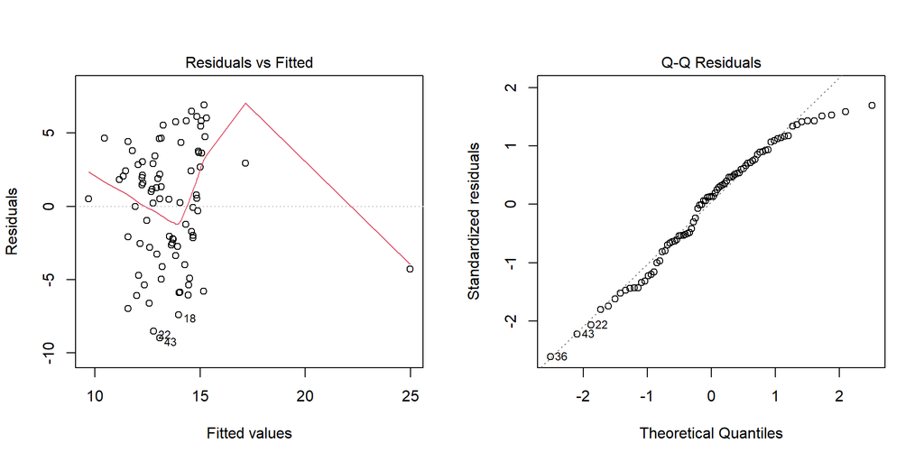

## Residuals for `mod5` (20th imputation)

```r
par(mfrow = c(1,2)); plot(m5_mods$analyses[[20]], which = c(3,5)); par(mfrow = c(1,1))
```

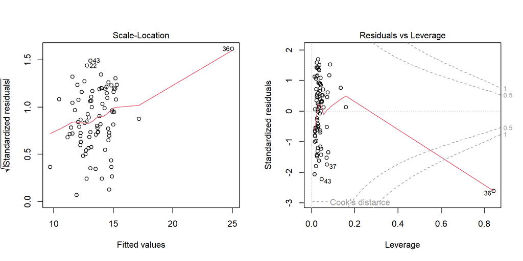

## More Details on MI modeling

```
Class: mipo    m = 50
         term  m     estimate         ubar            b            t dfcom
1 (Intercept) 50  16.41952438 1.881836e+00 5.579277e-01 2.450923e+00    79
2      bodywt 50   0.00161955 3.562166e-07 3.685064e-08 3.938042e-07    79
3  brain_prop 50 -91.25426722 2.705601e+03 8.319159e+02 3.554155e+03    79
4    rem_prop 50 -12.21467462 3.993923e+01 1.102507e+01 5.118480e+01    79
        df       riv     lambda       fmi
1 55.55978 0.3024101 0.23219267 0.2584157
2 68.82462 0.1055191 0.09544756 0.1206354
3 54.92329 0.3136287 0.23874989 0.2650347
4 56.77613 0.2815670 0.21970523 0.2458125
```

## Guidelines for reporting, I (Sterne)

How should we report on analyses potentially affected by missing data?

- Report the number of missing values for each variable of interest, or the number of cases with complete data for each important component of the analysis. Give reasons for missing values if possible, and indicate how many individuals were excluded because of missing data when reporting the flow of participants through the study. If possible, describe reasons for missing data in terms of other variables (rather than just reporting a universal reason such as treatment failure.)
- Clarify whether there are important differences between individuals with complete and incomplete data, for example, by providing a table comparing the distributions of key exposure and outcome variables in these different groups
- Describe the type of analysis used to account for missing data (eg, multiple imputation), and the assumptions that were made (eg, missing at random)

## Guidelines for reporting, II (Sterne)

How should we report on analyses that involve multiple imputation?

- Provide details of the imputation modeling (software used, key settings, number of imputed datasets, variables included in imputation procedure, etc.)
- If a large fraction of the data is imputed, compare observed and imputed values.
- Where possible, provide results from analyses restricted to complete cases, for comparison with results based on multiple imputation. If there are important differences between the results, suggest explanations.
- It is also desirable to investigate the robustness of key inferences to possible departures from the missing at random assumption, by assuming a range of missing not at random mechanisms in sensitivity analyses.